# L2P2: Uma análise bem maior

Helisson Nascimento

# Considerações Iniciais

A partir de dados da *Winkpedia*, dispostos em `/data/search_data.csv`, respoder as questões abaixo:

- Qual é a nossa taxa de cliques geral diária? Como isso varia entre os grupos?
- Quais resultados as pessoas tendem a tentar primeiro? Como isso muda no dia-a-dia?
- Qual é a nossa taxa global zero de resultados? Como isso varia entre os grupos?
- A duração da sessão é aproximadamente o tempo entre o primeiro e o último evento de uma sessão. Escolha uma variável do conjunto de dados e descreva sua relação com o tamanho da sessão. Visualize o relacionamento.

## Mas, o que esse *dataset* descreve?

A *Winkpedia* reuniu dados de buscas e a navegação depois das buscas e dispos nas seguintes variáveis:

- session_id : Um id único identificando sessões individuais
- search_index : Um contador de buscas em uma mesma sessão ordenado cronologicamente
- session_start_timestamp: O timestamp que a sessão iniciou
- session_start_date : A data e hora que a sessão iniciou
- group : O grupo que pode ser “a” ou “b”
- results : A quantidade de resultados que a busca retornou
- num_clicks : O número de páginas que o usuário visitou a partir da busca
- first_click : A posição do link da página visitada no mecanismo de busca de páginas
- session_length : A duração em segundos da sessão

# Explorando o *dataset*

Vamos visualizar a disposição dessas variáveis dentro do *dataset*

```r
head(data %>% arrange(session_id))
```

| session_id | search_index | session_start_timestamp | session_start_date | group | results | num_clicks | first_click |
| --- | --- | --- | --- | --- | --- | --- | --- |
| 0000cbcb67c19c45 | 1 | 20160303152045 | 2016-03-03 15:20:45 | b | 20 | 0 | NA |
| 0001382e027b2ea4 | 1 | 20160307084955 | 2016-03-07 08:49:55 | b | 18 | 1 | 1 |
| 0001e8bb90445cb2 | 1 | 20160305092415 | 2016-03-05 09:24:15 | b | 20 | 1 | 1 |
| 000216cf18ae1ab1 | 1 | 20160308161946 | 2016-03-08 16:19:46 | a | 20 | 0 | NA |
| 000216cf18ae1ab1 | 2 | 20160308161953 | 2016-03-08 16:19:53 | a | 20 | 0 | NA |
| 000216cf18ae1ab1 | 3 | 20160308162032 | 2016-03-08 16:20:32 | a | 20 | 0 | NA |

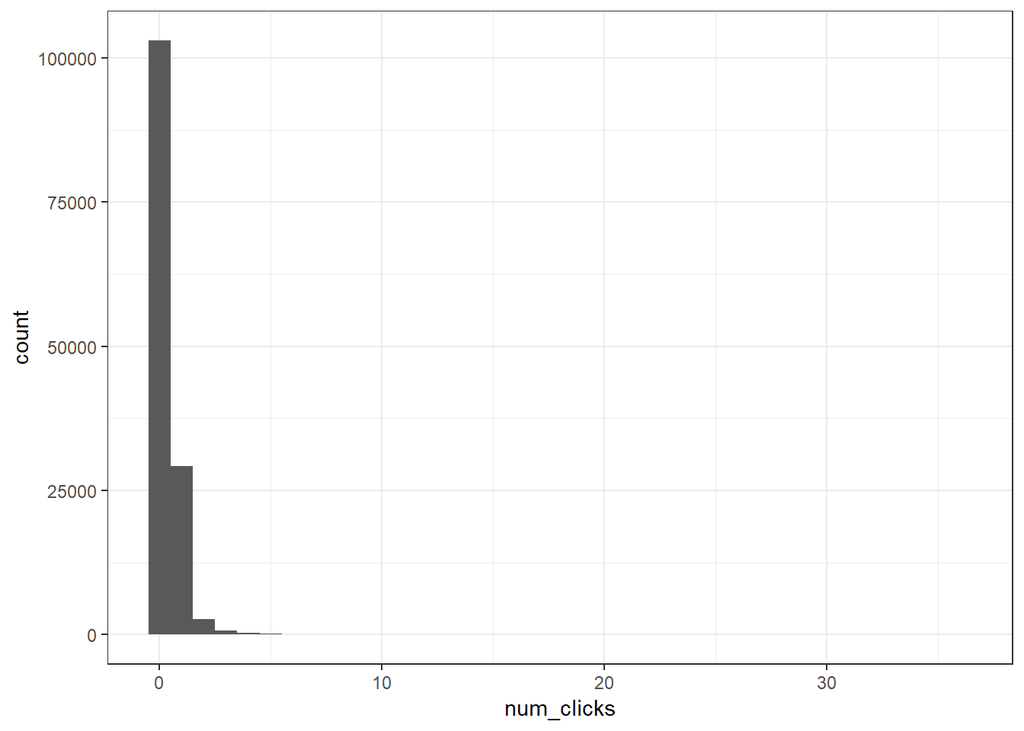

```r
data %>% ggplot(aes(x = num_clicks)) + geom_histogram(binwidth = 1)
```

# Qual é a nossa taxa de cliques geral diária? Como isso varia entre os grupos?

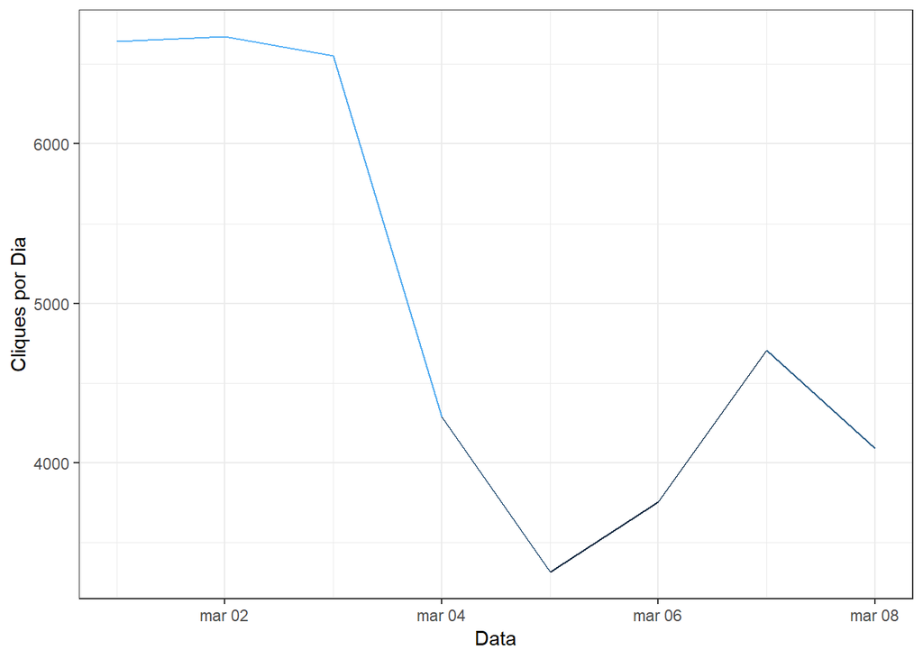

```r
data %>%
  group_by(session_start_date) %>%
  mutate(clicks_per_day = sum(num_clicks)) %>%
  ggplot(aes(x = session_start_date, y = clicks_per_day, colour=clicks_per_day)) +
  geom_line() +
  labs(x = "Data", y = "Cliques por Dia") +
  theme(legend.position = "none")
```

Vemos no gráfico acima que número de cliques foi maior no início de Março.

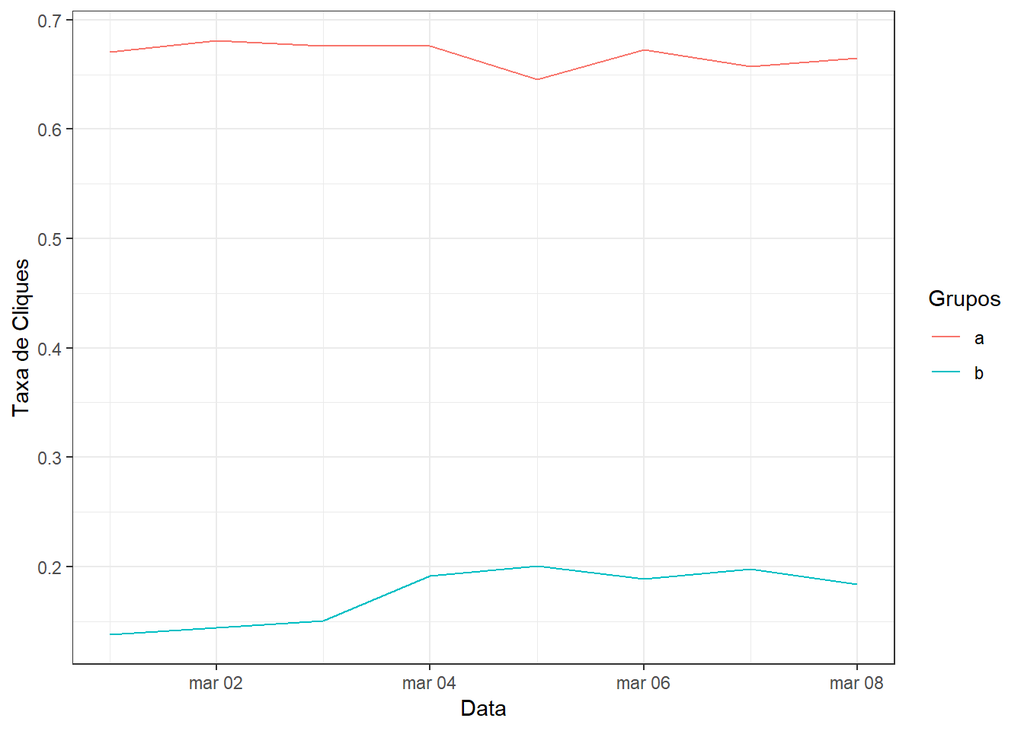

```r
clicks <- data %>%
                filter(num_clicks > 0) %>%
                group_by(session_start_date, group) %>%
                summarise( clicked_sessions = n_distinct(session_id) )

sessions <- data %>%
                group_by(session_start_date, group) %>%
                summarise( total_sessions = n_distinct(session_id) )

sessions_by_date = clicks %>%
                        inner_join(sessions, by = c("session_start_date", "group")) %>%
                        mutate(clickthrough_rate = clicked_sessions/total_sessions)

ggplot(data = sessions_by_date, aes(x = session_start_date, y = clickthrough_rate, group = group, color = group)) +
        geom_line() + labs(x = "Data", y = "Taxa de Cliques") + guides(color = guide_legend("Grupos"))
```

Analisando o gráfico acima, é fácil ver que o grupo *A* possui uma **taxa de cliques** maior.

# Quais resultados as pessoas tendem a tentar primeiro? Como isso muda no dia-a-dia?

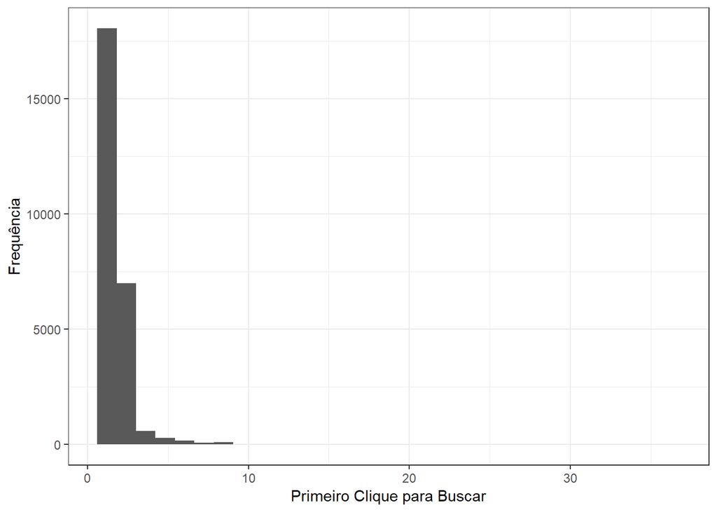

```r
first_search <- data %>%
                    filter(num_clicks > 0) %>%
                    group_by(session_id) %>%
                    summarise(first_search_index = min(search_index))

ggplot(first_search , aes(x = first_search_index)) +
                            geom_histogram() +
                                labs(y="Frequência", x="Primeiro Clique para Buscar")
```